# Stat 579 - Homework #2 - Section A

9/12/2019

## Swiss Banknotes

1. Download the RMarkdown file with these homework instructions to use as a template for your work. Make sure to replace “Your Name” in the YAML with your name.
2. The R package `alr3` contains a data set called `banknote`, consisting of (physical) measurements on 200 Swiss bank notes, 100 of which are genuine, while the other half is counterfeit. Load this data set (you might have to install the package) using the code below. Also run the cryptic third line - it will make your life a lot easier for the rest of the homework. This turns variable Y explicitly into a factor variable, i.e. makes it discrete. We will discuss this in the course material later in more detail.

```r
# install.packages("alr3")
library(tidyverse)
library(alr3) # if this throws an error of the form 'there is no package called alr3', uncomment the line above, run it once, then comment the line out again and run the code chunk again.
data(banknote)
banknote$Y <- factor(banknote$Y)
```

3. Use one of our object inspecting functions and interpret the result in the data that you see.

```r
str(banknote)
```

```
## 'data.frame':    200 obs. of  7 variables:
##  $ Length  : num  215 215 215 215 215 ...
##  $ Left    : num  131 130 130 130 130 ...
##  $ Right   : num  131 130 130 130 130 ...
##  $ Bottom  : num  9 8.1 8.7 7.5 10.4 9 7.9 7.2 8.2 9.2 ...
##  $ Top     : num  9.7 9.5 9.6 10.4 7.7 10.1 9.6 10.7 11 10 ...
##  $ Diagonal: num  141 142 142 142 142 ...
##  $ Y       : Factor w/ 2 levels "0","1": 1 1 1 1 1 1 1 1 1 1 ...
```

```r
summary(banknote)
```

```
##      Length           Left           Right           Bottom
##  Min.   :213.8   Min.   :129.0   Min.   :129.0   Min.   : 7.200
##  1st Qu.:214.6   1st Qu.:129.9   1st Qu.:129.7   1st Qu.: 8.200
##  Median :214.9   Median :130.2   Median :130.0   Median : 9.100
##  Mean   :214.9   Mean   :130.1   Mean   :130.0   Mean   : 9.418
##  3rd Qu.:215.1   3rd Qu.:130.4   3rd Qu.:130.2   3rd Qu.:10.600
##  Max.   :216.3   Max.   :131.0   Max.   :131.1   Max.   :12.700
##       Top           Diagonal     Y
##  Min.   : 7.70   Min.   :137.8   0:100
##  1st Qu.:10.10   1st Qu.:139.5   1:100
##  Median :10.60   Median :140.4
##  Mean   :10.65   Mean   :140.5
##  3rd Qu.:11.20   3rd Qu.:141.5
##  Max.   :12.30   Max.   :142.4
```

### These summaries shows that there are 200 rows, or instances, of 7 variables. 6 of these are presumbably the various measurements taken on each bill. The last variable, Y, is a vector of booleans that simply state whether the bill is authentic or counterfeit.

4. Use the package `ggplot2` to draw a barchart of Y (0 is genuine, 1 is counterfeit). Map Y to the fill color of the barchart.

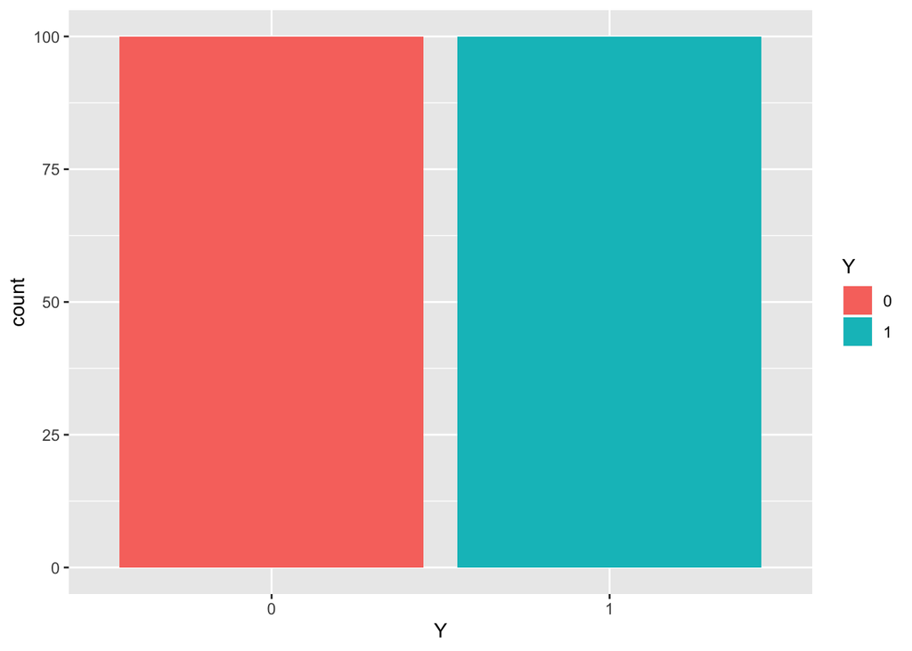

```r
banknote %>%
  ggplot(aes(x=Y, fill=Y)) + geom_bar()
```

### This a bar chart with bars representing counterfeit and authentic bank notes. They are represented as 1 and 0 respectively as shown in the x axis of the chart. They are also separated by color, turquoise and salmon respectively. The y axis shows the number of counts for each type of bill in the dataset. There are exactly 100 counterfeit and 100 authentic notes.

5. Use the package `ggplot2` to draw a histogram of one of the variables in the dataset that shows a distinction between genuine and counterfeit banknotes. Use fill color to show this difference. Choose the binwidth such that there are no gaps in the middle range of the histogram.

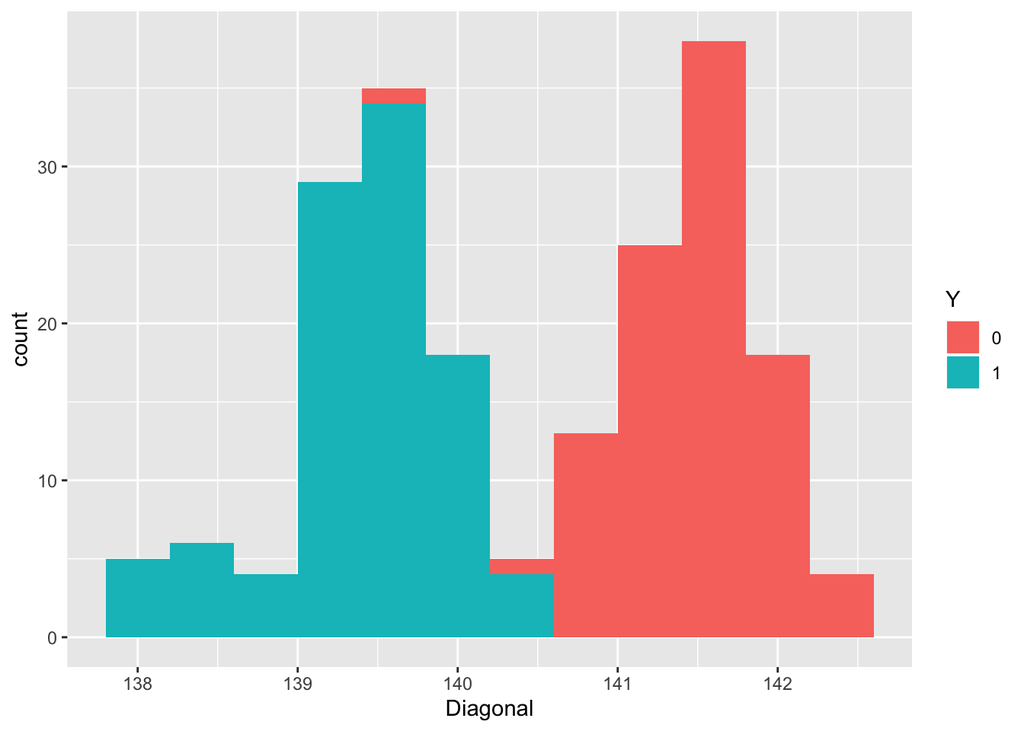

```r
banknote %>%
  ggplot(aes(x=Diagonal, fill=Y)) + geom_histogram(binwidth = .4)
```

### This is a histogram showing the distribution of diagonal measurements on the bills. The two bill types are also represented in colors with salmon being genuine and turquoise being false bills. This is a bimodal distribution and, for the most part, there appears to be a separation between the two bill types, but there is at least one genuine bill which has a measurement more closely related to the fake bills, as seen in the left peak of the distribution.

6. Use the package `ggplot2` to draw a scatterplot of two (continuous) measurements, color by Y. Try to find a pair of measurements that allow you to separate perfectly between genuine and counterfeit banknotes.

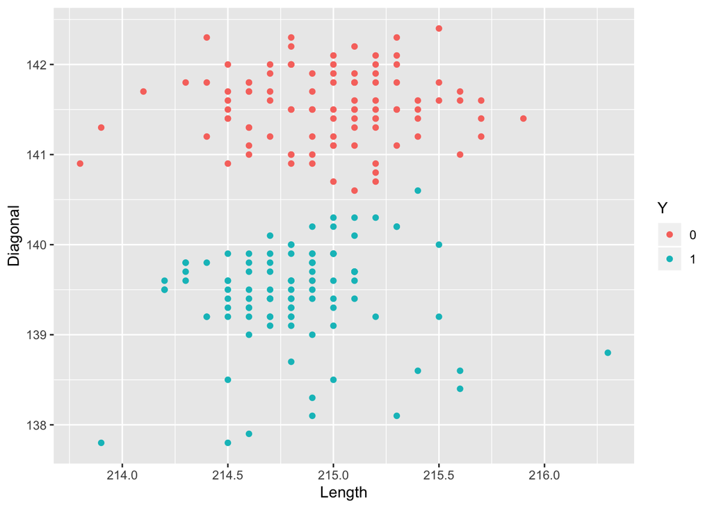

```r
banknote %>%
  ggplot(aes(y=Diagonal,x=Length, colour=Y)) + geom_point()
```

### This is a scatterplot with the diagonal measurements (y-axis) being plotted by the length measurements (x-axis). Again, the note types are distinguished by color. This is as close to a perfect separation as can be found by making a scatterplot of two different measurement variables. As can be seen, if a line were to be drawn at 140.5 on the y-axis, there would be almost two perfect clusters of note types with a single exception -around 215.3 on the x-axis.

7. For each of the three figures above, write a two-three sentence summary, describing the
   1. **structure of the plot**: what type of plot is it? Which variables are mapped to x, to y, and to the (fill) color?
   2. **main message of the plot**: what is your main finding, i.e. what do you want viewers to learn from the plot?
   3. **additional message**: point out anomalies or outliers, if there are any.

Due date: the homework is due a week from now on Thursday.

For the submission: submit your solution in an R Markdown file and (just for insurance) submit the corresponding html/word file with it.